# Programming Final

Hannah Stanford

Fall 2021

[figure not shown]

# Introduction

Published in October 2020, the TUAT Insecta database was compiled from various plant and insect databases and journal articles and includes insect-host plant relationships, host plant-metabolite relationships, and metabolite functions. Taxonomic information ranging from species to Kingdom is available for both the insects and host plants. Metabolites are identified by chemical name, molecular formula, and cid.

Additional information is intergrated from the webchem: Chemical Information from the Web and divides the metabolites into classes and subclasses 1,2,3 and 4.

This database holds an incredible amount of information and has only been used by the original authors to screen for medicinally important metabolites. In this project, I am using the database to find potential trends in host-insect-metabolite relationships e.g. do certain metabolites predict insect presence.

### *Variable Descriptions*

| Name | Description |
| --- | --- |
| scinameinsect | Insect species |
| genusinsect | Insect genus |
| familyinsect | Insect family |
| orderinsect | Insect order |
| classinsect | Insect class |
| phyluminsect | Insect phylum |
| kingdominsect | Insect kingdom |
| rel | Insect-host plant relationship |
| scinamehost | Host plant species |
| genushost | Host plant genus |
| familyhost | Host plant family |
| orderhost | Host plant order |
| classhost | Host plant class |
| phylumhost | Host plant phylum |
| kingdomhost | Host plant kingdom |
| cid | Chemical ID # |
| chemname | Metabolite name |
| Class | Chemical Class (most general) |
| Subclass_1 | Chemical Subclass 1 |
| Subclass_2 | Chemical Subclass 2 |
| Subclass_3 | Chemical Subclass 3 |
| Subclass_4 | Chemical Subclass 4 (most specific) |
| n_records | # of records |

## Loading Data

In the chunk below, the Tuat Insecta database is imported as a .csv (and any additional files needed).

```r
tuat_insecta <- read.csv("/Users/ha890672/Documents/tuatinsecta/data/tuat_insecta.csv")
chebi_ids <- read.csv("/Users/ha890672/Documents/tuatinsecta/output/chebi_ids.csv")
class_matrix <- read.csv("/Users/ha890672/Documents/tuatinsecta/output/class_matrix.csv")
plants_by_insects <- read.csv("/Users/ha890672/Documents/tuatinsecta/output/plants_by_insects.csv")
results <- read.csv("/Users/ha890672/Documents/tuatinsecta/output/results.csv")
species_chemicals <- read.csv("/Users/ha890672/Documents/tuatinsecta/output/species_chemicals.csv")
```

## Loading Packages

In the chunk below, all necessary libraries are loaded, including webChem (converts chemicals into classes), ecodist (runs a PCoA), and various graphing and text tools.

```r
library(ggplot2)
library(dplyr)
library(tidyr)
library(ape)
library(vegan)
library(readr)
library(omu)
library(webchem)
library(tidyverse)
library(ecodist)
library(FactoMineR)
library(factoextra)
library(tidyverse)
library(readxl)
library(RColorBrewer)
library(ggforce)
library(ggthemes)
library(gridExtra)
library(colorspace)
library(ragg)
library(cowplot)
library(ggtext)
library(pdftools)
library(jpeg)
library(patchwork)
library(grid)
library(extrafont)
library(showtext)
library(scales)
```

## Help Code

There’s a hidden chunk here that has some of the code you wrote that prunes and merges the Tuat Insecta database with the webChem Chebi records.

## Tidying the Main Dataset

Using the tuat_insecta_pruned_merged dataset, redundant and irrelevant rows columns removed.

```r
cleaned1 <-  tuat_insecta_pruned_merged %>%
  select(-c(1, 2,11,12,21,24, 23, 31, 32, 33, 34, 35, 36, 37))
```

## Subsetting the Data

Due to the scope of this dataset, I chose to subset the data. For this project, I subset the data to the family Asteraceae, the family most relevant to our current lab work.

```r
asters <- cleaned1 %>%
  filter(familyhost == "Asteraceae")%>%
  arrange(scinamehost)
```

## Additional Tidying

There were strange one letter genera and some missing binomials in sciname host, as well as NAs in Order and chemical class (I left the NAs in subclasses because I could still gather information with only class). In the code below, I tidied the data using boolean language in dplyr. I also condensed some of the Subclass 3 categories into their more common names.

```r
genushost_count <- asters %>% count(genushost)
scinamehost_count <- asters %>% count(scinamehost)
genusinsect_count <- asters %>% count(genusinsect)
scinameinsect_count <- asters %>% count(scinameinsect)

Asters <- asters %>%
  filter(!genushost %in% c("A", "H") &
         !scinamehost %in% c("Achillea", "Helichrysum") &
         !genusinsect %in% c( "A", "B", "C", "D", "E", "G", "H", "L", "M", "N", "O", "P", "R", "S","T") &
         !scinameinsect %in% c("Xylocopa") &
         orderinsect != "NA" &
         Class != "NA") %>%
  select(-c("Subclass_4"))%>%
  mutate(Subclass_3 = replace(Subclass_3, Subclass_3 == "C10 isoprenoids (monoterpenes)", "Monoterpenes"))%>%
  mutate(Subclass_3 = replace(Subclass_3, Subclass_3 == "C15 isoprenoids (sesquiterpenes)", "Sesquiterpenes"))%>%
  mutate(Subclass_3 = replace(Subclass_3, Subclass_3 == "C40 isoprenoids (tetraterpenes)", "Tetraterpenes"))%>%
  mutate(Subclass_3 = replace(Subclass_3, Subclass_3 == "C10 isoprenoids (monoterpenes)", "Monoterpenes"))%>%
  mutate(Subclass_3 = replace(Subclass_3, Subclass_3 == "C15 isoprenoids (sesquiterpenes)", "Sesquiterpenes"))%>%
  mutate(Subclass_3 = replace(Subclass_3, Subclass_3 == "C30 isoprenoids (triterpenes)", "Triterpenes"))
```

## Summary Stats

In the chunk below, I generated counts of different aspects of the data, including counts of the host genera, insect genera, insect family, insect order, most common phytochemicals in Asteraceae (in this database), most common phytochemicals by subclasses (terpenoids & isoprenoids, alkaloids, flavonoids, and phenylpropanoids), most common chemicals by insect family, and various other insect stats.

```r
#### General
#Most common host plants in Asteraceae
genera_host <- Asters %>% count(genushost) %>% arrange(desc(n))

#Most common insect order, genus, and family feeding on Asters

order_insect <- Asters %>% count(orderinsect) %>% arrange(desc(n))

genus_insect <- Asters %>% count(genusinsect) %>% arrange(desc(n))

family_insect <- Asters %>% count(familyinsect) %>% arrange(desc(n))


####### Phytochemicals

#Count most common Terpenoids & Isoprenoids found in Asteraceae

phyto_terps <- Asters %>% filter(Class == "Phytochemical compounds" & Subclass_1 == "Terpenoids" | Subclass_2 == "Isoprenoids") %>% count(chemname) %>% arrange(desc(n))

#Count of most common Flavonoids found in Asteraceae
phyto_flavo <- Asters %>% filter(Class == "Phytochemical compounds" & Subclass_1 == "Flavonoids") %>% count(chemname) %>% arrange(desc(n))
#Count of most common Phenylpropanoids in Asteraceae
phyto_phenylprop <- Asters %>% filter(Class == "Phytochemical compounds" & Subclass_1 == "Phenylpropanoids") %>% count(chemname) %>% arrange(desc(n))
#Count of most common Alkaloids in Asteraceae
phyto_alks <- Asters %>% filter(Class == "Phytochemical compounds" & Subclass_1 == "Alkaloids") %>% count(chemname) %>% arrange(desc(n))
#Count of  most common Phytochemical compounds found in Asteracea
phyto_all <- Asters %>% filter(Class == "Phytochemical compounds") %>% count(chemname) %>% arrange(desc(n))
phyto_all_top10 <- Asters %>% filter(Class == "Phytochemical compounds") %>% count(chemname) %>% arrange(desc(n)) %>% slice(1:10)

####### Insects (Lepidoptera since its the most common order and we study butterflies in this lab)


lepid <- Asters %>% filter(orderinsect == "Lepidoptera")%>% count(genusinsect)%>%arrange(desc(n))

nymphalidae <- Asters %>% filter(familyinsect == "Nymphalidae") %>% count(genusinsect)%>%arrange(desc(n))

vanessa <- Asters %>% filter(genusinsect == "Vanessa") %>% count(scinameinsect)%>%arrange(desc(n))


### Lepidoptera, Nymphalidae, Host Plants

lepid_by_hostgenus <- Asters %>% filter(orderinsect == "Lepidoptera") %>% count(genushost)%>%arrange(desc(n))

nymphalidae_by_hostgenus <- Asters %>% filter(familyinsect == "Nymphalidae") %>% count(genushost)%>% arrange(desc(n))

#Vanessa genus and Vanessa spp.
vanessa_by_hostgenus <- Asters %>% filter(genusinsect == "Vanessa")%>% count(genushost)%>% arrange(desc(n))

vcarudi_by_hostgenus <- Asters %>% filter(scinameinsect == "Vanessa cardui")%>% count(genushost)%>% arrange(desc(n))

vatalanta_by_hostgenus <- Asters %>% filter(scinameinsect == "Vanessa atalanta")%>% count(genushost)

vvirginiensis_by_hostgenus <- Asters %>% filter(scinameinsect == "Vanessa virginiensis")%>% count(genushost)

vcarye_by_hostgenus <- Asters %>% filter(scinameinsect == "Vanessa carye")%>% count(genushost)


### Insects, Host, Metabolites (graphed below)

vanessa_by_chesubclass3 <- Asters %>%
  filter(genusinsect == "Vanessa")%>%
  count(Subclass_3)%>%
  arrange(desc(n))%>%
  na.omit()%>%
  slice(1:10)

vcarudi_chemsubclass3 <- Asters %>%
  filter(scinameinsect == "Vanessa cardui")%>%
  count(Subclass_3)%>%
  arrange(desc(n))%>%
  na.omit()%>%
  slice(1:10)

vatalanta_by_chemsubclass3 <- Asters %>%
  filter(scinameinsect == "Vanessa atalanta")%>%
  count(Subclass_3)%>%
  arrange(desc(n))%>%
  na.omit()%>%
  slice(1:10)

vvirginiensis_by_chemsubclass3<- Asters %>%
  filter(scinameinsect == "Vanessa virginiensis")%>%
  count(Subclass_3)%>%
  arrange(desc(n))%>%
  na.omit()%>%
  slice(1:10)

vcarye_by_chemsubclass3 <- Asters %>%
  filter(scinameinsect == "Vanessa carye")%>%
  count(Subclass_3)%>%
  arrange(desc(n))%>%
  na.omit()%>%
  slice(1:10)
```

## Visualizing the Top 10 Chemicals of Subclass 3 in the family Asteraceae consumed by Genus *Vanessa* and Species *cardui*, *atalanta*, and *virgeniensis*

Out of the summary stats above, I chose to graph the most common chemicals found in host plants that butterflies in the genus Vanessa feed on since *V. cardui* butterflies are a model system in our lab.

In the chunk below, species images are imported and added to formatted graphs.

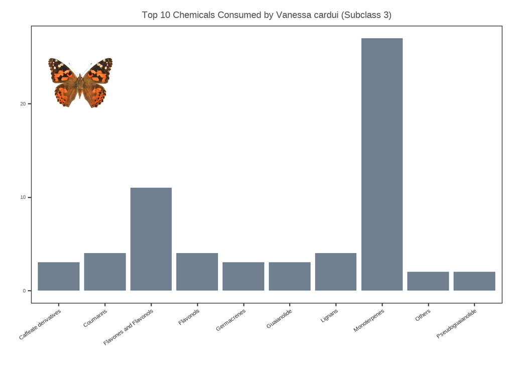

```r
#Loading JPEGS into R using jpeg package
vimg1 <- readJPEG("/Users/ha890672/Downloads/vanessacardui.jpg", native = TRUE)

vimg2 <- readJPEG("/Users/ha890672/Documents/vatalanta2.JPG", native = TRUE)

vimg3 <- readJPEG("/Users/ha890672/Downloads/vanessavirginensis.jpg", native = TRUE)



#Uploading new font from google using showtext package

font_add_google("Flamenco", "flamenco")
showtext_auto()


#Creating the plots

##v cardui
v_cardui_g <- ggplot(vcarudi_chemsubclass3, aes(Subclass_3, n)) +
  geom_col(alpha = 1, fill = "slategray")+
  theme_few() +
  theme(plot.title = element_text(
    color = "grey30",
    size = 18,
    hjust = 0.5
  )) +
  theme(axis.text.x = element_text(
    angle = 35,
    hjust = 1,
    size = 11,
    color = "grey20"
  )) +
  theme(axis.title.x = element_text(color = "white")) +
  theme(axis.title.y = element_text(color = "white")) +
  labs(title = "Top 10 Chemicals Consumed by Vanessa cardui (Subclass 3)",
       family = "flamenco") +
  inset_element(
    p = vimg1,
    left = 0.01,
    right = 0.2,
    top = 0.95,
    bottom = 0.65
  )

##v atalanta
v_atalanta_g <- ggplot(vatalanta_by_chemsubclass3, aes(Subclass_3, n)) +
  geom_col(alpha = 1, fill = "honeydew2") +
  theme_few() +
  theme(plot.title = element_text(
    color = "grey30",
    size = 18,
    hjust = 0.5
  )) +
  theme(axis.text.x = element_text(
    angle = 35,
    hjust = 1,
    size = 11,
    color = "grey20"
  )) +
  theme(axis.title.x = element_text(color = "white")) +
  theme(axis.title.y = element_text(color = "white")) +
  labs(title = "Top 10 Chemicals Consumed by Vanessa atalanta (Subclass 3)",
       family = "flamenco") +
  inset_element(
    p = vimg2,
    left = 0.01,
    right = 0.2,
    top = 0.95,
    bottom = 0.65
  )

## v virgenensis
v_virgenensis_g <- ggplot(vvirginiensis_by_chemsubclass3, aes(Subclass_3, n)) +
  geom_col(alpha = 1, fill = "rosybrown2") +
  theme_few() +
  theme(plot.title = element_text(
    color = "grey30",
    size = 18,
    hjust = 0.5
  )) +
  theme(axis.text.x = element_text(
    angle = 35,
    hjust = 1,
    size = 11,
    color = "grey20"
  )) +
  theme(axis.title.x = element_text(color = "white")) +
  theme(axis.title.y = element_text(color = "white")) +
  labs(title = "Top 10 Chemicals Consumed by Vanessa virgenensis (Subclass 3)",
       family = "flamenco") +
  inset_element(
    p = vimg3,
    left = 0.01,
    right = 0.2,
    top = 0.95,
    bottom = 0.65
  )

#Print
print(v_cardui_g)
```

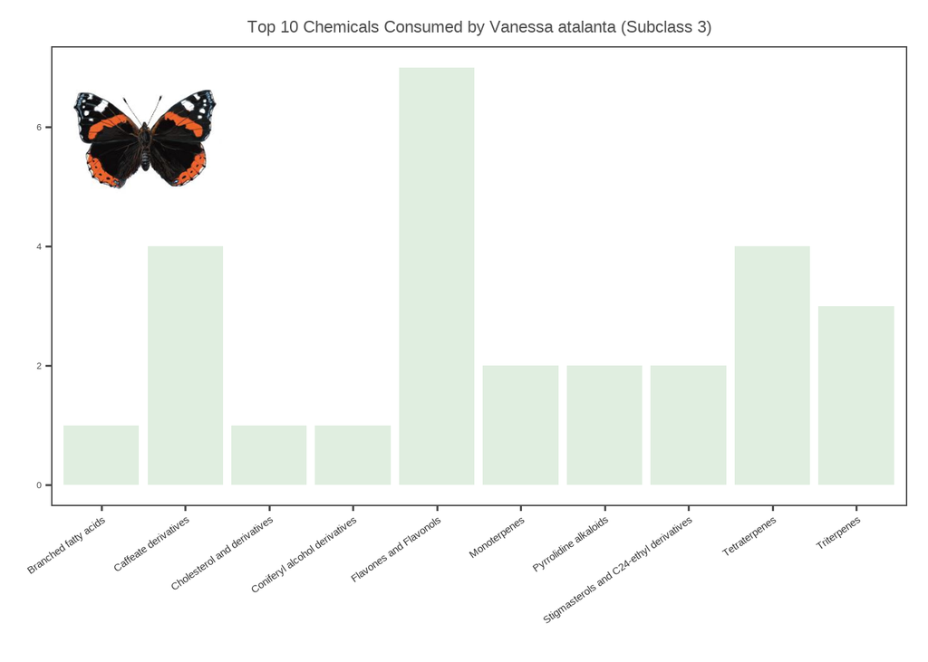

```r
print(v_atalanta_g)
```

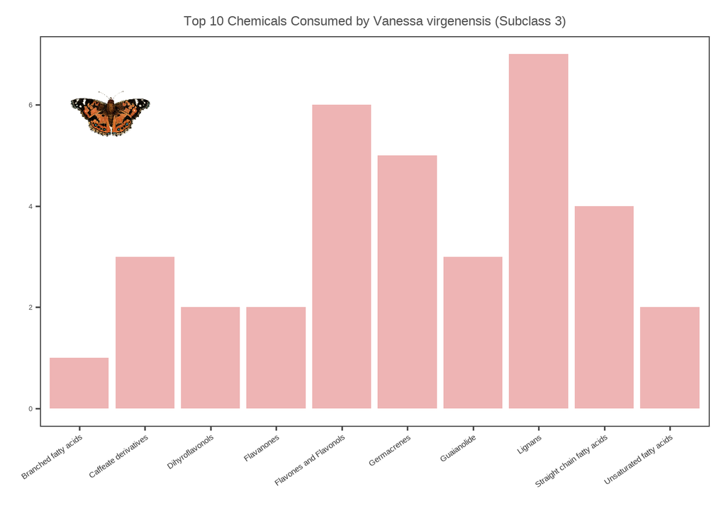

```r
print(v_virgenensis_g)
```

## One-Hot Encoding the Dataset

Since the variables are categorical and cannot yet be used in the PCoA, I used your template code to create a matrix of insect families by Subclass2 and one-hot encoded the dataset.

```r
#insects-host relationship
fam_insect <- Asters %>% distinct(familyinsect) %>% pull() %>% na.omit()
#chemical subclasses
subclass2 <- Asters%>% distinct(Subclass_2) %>% pull() %>% na.omit()

if(file.exists("output/faminsect_subclass2.csv"))
{
  fam_insect_sub2<- as.matrix(read_csv("output/faminsect_subclass2.csv"))
  rownames(fam_insect_sub2) <- fam_insect
} else
{
  fam_insect_sub2<- matrix(0,nrow = length(fam_insect),ncol = length(subclass2),dimnames = list(fam_insect,  subclass2))
  for(i in 1:length(fam_insect))
  {
    fam_insect_sub2[
      fam_insect[i],
      Asters%>%
        filter(fam_insect[i] == familyinsect) %>%
        select(Subclass_2) %>%
        distinct() %>%
        pull() %>%
        na.omit()
    ] <- 1
  }
fam_insect_sub2<- fam_insect_sub2
  rownames(fam_insect_sub2) <- fam_insect
  write_csv(as_tibble(fam_insect_sub2),"output/faminsect_subclass2.csv")

}

#changing text row names to numbers so it's easier to see on the PCA
row.names(fam_insect_sub2) <- c(1:72)
```

## Running the PCoA

```r
#PCoA with cmdscale() stats package
f_i_sub2_PCOA <- cmdscale(dist1, k=2)

#Converting to Datafram and adding insect family and orders to the dataframe for graphing.



orderfamins <- Asters %>%
 select(orderinsect, familyinsect)%>%
  unique()

orders <- orderfamins$orderinsect

f_i_sub2_PCOA<- as.data.frame(f_i_sub2_PCOA)
f_i_sub2_PCOA$fam_insect <- fam_insect
f_i_sub2_PCOA$orders <- orders


#Changing Column names to PC1 and PC2
names(f_i_sub2_PCOA)[1:2] <- c('PC1', 'PC2')
```

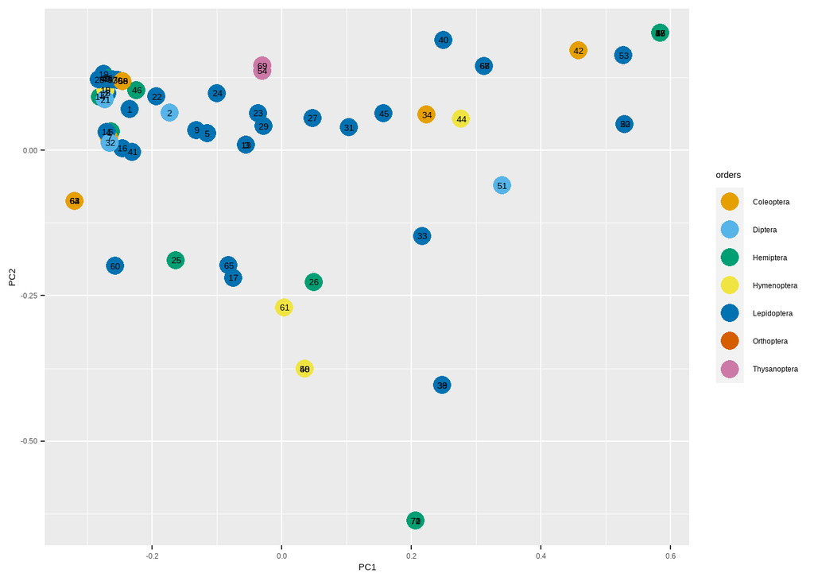

```r
cbPalette <- c("#999999", "#E69F00", "#56B4E9", "#009E73", "#F0E442",
               "#0072B2", "#D55E00", "#CC79A7")
test <- ggplot(f_i_sub2_PCOA, aes(x = PC1, y = PC2, colour = orders,
                                 label = row.names(f_i_sub2_PCOA)))

test + geom_point(size = 5) +
        scale_colour_manual(values = cbPalette[2:8]) +
        geom_text(col = 'black')
```

## Rubric

- RMarkdown document successfully Knits to HTML (10%)
  - Knitted!
- All code chunks run as intended / as described in the text part of the document (10%)
- Appearance / formatting (i.e., title, informative section headers, appropriate text descriptions and R code chunks) (10%)
- Dataset is sufficiently introduced and explained, including a description of the context, how the data was originally collected or generated, variables names and descriptions, number of observations, and any other pertinent information) (10%)
- Data is properly transformed prior to use in analyses which demonstrates a thorough knowledge of Dplyr/Tidyr (20%)
  - Data was subset from the Pruned & Merged dataset you provided and subset into a smaller data frame including only observations in the family Asteraceae.
  - Data was tidied to remove irrelevant columns, NA values in Chemical Class, genera that had only single letters, and species that lacked a binomial.
  - Chemicals in Subclass 3 were condensed into easier to read names (e.g. C40 Isoprenoids to Tetraterpenoids)
- Data are analyzed using a variety of approaches, including any of the following: hypothesis-driven, exploratory, * descriptive, and/or predictive statistics (10%)
  - Summary statistics
  - Exploratory PCoA (only to understand how to use the code in the future – I’m unsure if the PCoA I ran is significant or even correct. I’m going to dive into multi-variate analyses next semester to get a better understanding of PCAs and PCoAs.)
- Data and analyses are well-visualized (20%)
  - Summary statistics graphed in ggplot
- New skills are implemented (clustering analysis) (10%)
  - Fiddled around with a PCoA, but I need more time to understand and format a matrix that makes biological sense.
  - I also learned how to write images into R and insert them into ggplot graphs.

## Conclusion

This dataset is definitely a challenge; however, once tidied and sorted through, it may have a wealth of information. For example, if someone wanted to find the most common metabolites in a certain insect’s diet to see what classes of chemicals they are able to metabolize, this would be a great resource before conducting an actual experiment. While the PCoA I did was a bit of a flop, once I understand the theory better, I believe I can conduct a better analysis of the data.